# My answers

# Question 4: Lab test two

Suppose that another lab test values record changes from a reference value and these are normally distributed with $\mu = -16$ and $\sigma = 1.5$.

## Question 4.1

What is the probability that a randomly selected test has a value that is within one standard deviation of the mean? Round to three decimal places.

```r
# The probability P(mean - SD <= X <= mean + SD) would be calculated in the same way as the previous question, producing a probability of 0.683:
(pnorm(-14.5, mean = -16, sd = 1.5) - pnorm(-17.5, mean = -16, sd = 1.5)) %>%
  round(3)
```

```
## [1] 0.683
```

## Question 4.2

What is the probability that a randomly selected test has a value that is within two standard deviations of the mean? Round to three decimal places.

```r
# # The probability P(mean - 2*SD <= X <= mean + 2*SD) would be calculated in the same way as the previous question, producing a probability of 0.954:
(pnorm(-13, mean = -16, sd = 1.5) - pnorm(-19, mean = -16, sd = 1.5)) %>%
  round(3)
```

```
## [1] 0.954
```

## Question 4.3

What is the probability that a randomly selected test has a value that is within three standard deviations of the mean? Round to three decimal places.

```r
# The probability P(mean - 3*SD <= X <= mean + 3*SD) would result in a probability of of 0.997:
(pnorm(-11.5, mean = -16, sd = 1.5) - pnorm(-20.5, mean = -16, sd = 1.5)) %>%
  round(3)
```

```
## [1] 0.997
```

## Question 4.4

How do your answers compare to those of Question 3? Does this surprise you?

```r
# The answers are identical - this is not surprising, as both samples are normally distributed, and thus all values tend to fall within each standard deviation in a pattern according to the 68-95-99 rule, meaning that regardless of the mean and standard deviation, the same proportion of the distribution would fall within x standard deviations of the mean.
```

# Question 5: Randomization verification

A clinical trial was designed to determine whether radiation therapy or surgery was more effective in reducing disease recurrence in men with prostate cancer. Patients were randomized to each treatment in a 1:1 manner, which implies the chance a patient is randomized to either arm is 0.50. Suppose that in the first 20 patients randomized at a particular site participating in the trial, 17 patients were assigned to the surgery arm. The site complains that the randomization does not appear to be working. Does the site’s suspicion have merit?

When you answer this, you should consider all scenarios that would support the suspicions that the randomization is broken. Specifically, what other outcomes out of 20 would be more extreme to the one observed. You might want to calculate the probability of getting the result observed or one more extreme.

```r
# Since randomization has a binary outcome, this can be calculated with the binomial distribution function pbinom to find the probability P(X > 16), resulting in a probablity of 0.00129. This indicates that it is extremely unlikely that the patients were randomized correctly.
pbinom(16, 20, 0.5, lower.tail = FALSE) %>%
  round(5)
```

```
## [1] 0.00129
```

# Hypertension

The remainder of the questions are relevant to this scenario.

The proportion of U.S. adults over the age of 20 with hypertension is 0.335, or 33.5%.

# Question 6: Hypertension

Suppose you take a random sample of 64 U.S. adults over the age of 20.

## Question 6.1

What is the chance that 32 people have hypertension? (Round to 4 decimal places.)

```r
# The probability that exactly 32 out of 64 people in this sample have hypertension is 0.0025.
dbinom(32, 64, 0.335) %>%
  round(4)
```

```
## [1] 0.0025
```

## Question 6.2

What is the chance that more than 20 individuals in the sample have hypertension? (Round to 3 decimal places.)

```r
# The probability that more than 20 individuals in the sample have hypertension is 0.593.
pbinom(q = 20, size = 64, prob = 0.335, lower.tail = F) %>%
  round(3)
```

```
## [1] 0.593
```

## Question 6.3

What is the chance that between 21 and 24 individuals, inclusive, out of 64 have hypertension? (Round to 3 decimal places.)

```r
# The probability P(21 <= X <= 24) is equal to 0.385.
 (pbinom(24, 64, 0.335) - pbinom(20, 64, 0.335)) %>%
  round(3)
```

```
## [1] 0.385
```

# Question 7: Hypertension

Now suppose you take your random sample (of size 64) from one city in the United States. You get a sample proportion of 0.211.

## Question 7.1

How likely are you to get a sample proportion this small or smaller if this city is representative of the US population?

```r
#Given the sample proportion p = 0.211, solving for y = p * n results in a y (number of observations / successes) of 13.5. Modeling this in R produces a probability of 0.015.
pbinom(q = 13.5, size = 64, prob = 0.335) %>%
  round(3)
```

```
## [1] 0.015
```

## Question 7.2

What do you conclude?

```r
# Given that the probability of obtaining this sample proportion is so low, it is very unlikely that such a sample proportion would be obtained if the city is representativev of the US population.
```

# Question 8: Hypertension

Give a range for which you are 95% certain would contain the sample proportion of adults with hypertension if you were to take a random sample of 64 adults in the U.S. over the age of 20. (Round to three decimal places.)

```r
##he range that we are 95% sure contains the sample proportion is 0.219 - 0.453.

#Lower limit of CI
(qbinom(0.025, 64, 0.335)/64) %>%
  round(3)
```

```
## [1] 0.219
```

```r
#Upper limit of CI (1 - 0.025)
(qbinom(0.975, 64, 0.335)/64) %>%
  round(3)
```

```
## [1] 0.453
```

# Question 9: Hypertension

We want to compare the sampling distribution of our sample proportion to that of a normal distribution. The normal distribution should have the same mean and standard deviation as the sampling distribution. To do this, we want to use `qqplot()`. We will simulate the sampling distribution of both the sampling proportion as well as the normal distribution. After using `qqplot()`, use `qqline()` to add a line to the plot.

## Question 9.1

Make a qqplot comparing the sampling distribution of the sample proportion to that of a normal distribution, including a line that indicates a perfect relationship.

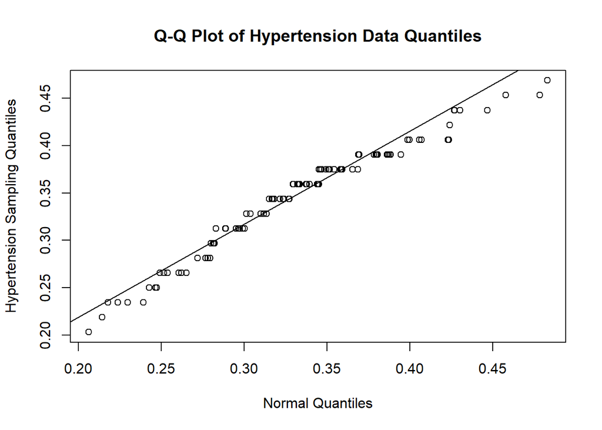

```r
# creating normal distribution for comparison
HTnorm <- rnorm(n = 100, mean = 0.335, sd = 0.0589)

# creating binomial distribution using hypertension question parameters

HTbinom <- (rbinom(n = 100, size = 64, prob = 0.335)/64)

#generating QQplot + qqline
qqplot(x = HTnorm, y = HTbinom, main = "Q-Q Plot of Hypertension Data Quantiles", xlab = "Normal Quantiles", ylab = "Hypertension Sampling Quantiles")
qqline(y = HTbinom, distribution = function(p) qnorm(p, 0.335, 0.0589))
```

## Question 9.2

How do these two distributions compare?

```r
# The two distributions appear to be very similar, as evidenced by the tendency to cluser around the reference line. Since the comparison sample was taken from a normal distribution, the similarlity of the hypertension sampling distribution indicates that the population being sampled is also normally-distributed.
```

## Question 9.3

To verify your answer to Question 9.2, use a normal distribution with the same mean and standard deviation of the binomial distribution to determine the likelihood that we observe between 21 and 24 individuals, inclusive, out of 64 have hypertension (Question 6.3). How do these values compare?

```r
#Normal distribution with same mean and standard deviation as previous binomial distribution for P(21 <= X <= 24):

#Calculating mean and SD of the binomial distribution ([1] = mean, [2] = SD):
HTnormVals <- c((64 * 0.335), (sqrt(64*0.335*(1 -0.335))))

#Finding P(21 <= X <= 24) with the above mean and SD
(pnorm(24,  mean = HTnormVals[1], sd = HTnormVals[2]) - pnorm(20, mean = HTnormVals[1], sd = HTnormVals[2])) %>%
  round(4)
```

```
## [1] 0.3996
```

```r
#The probability in this case, 0.3996 (rounded to 0.4), is very similar to the binomial probability in Question 6.3, indicating that the population in question is most likely normally distributed.
```